# Modelling of a length-based multi-species population targeted by a mixed fishery

Laurent Dubroca

2021-06-07

# Framework

This report runs a length-based multi-species population model targeted by a mixed fishery following Spence et al. (2020) (based on Hall et al. (2006)). The model choice is related to the need of having a population structured in length in order to then simulate sampling in it, and to have a model easily accessible in R. The fishery catches are modelled by gear, and species preference and catchability are highly customisable. These conditions are necessary to simulate realistic concurrent sampling plan.

# Package and co

Library are loaded and code sourced, if any.

```r
#link https://github.com/CefasRepRes/LeMaRns
#https://journals.plos.org/plosone/article?id=10.1371/journal.pone.0227767
library(LeMaRns)
#basic stuff
library(ggplot2)
library(dplyr)
```

# Population and fishery modelling

## Simulation test

To test the model, the example input parameters from Thorpe et al. (2016) and Thorpe et al. (2015) are used (21 species, 50 years), with a constant fishing effort. The SSB is plotted.

```r
#a short test
NS_params <- LeMansParam(NS_par, tau=NS_tau, eta=NS_eta, L50=NS_L50,other=1e12)
```

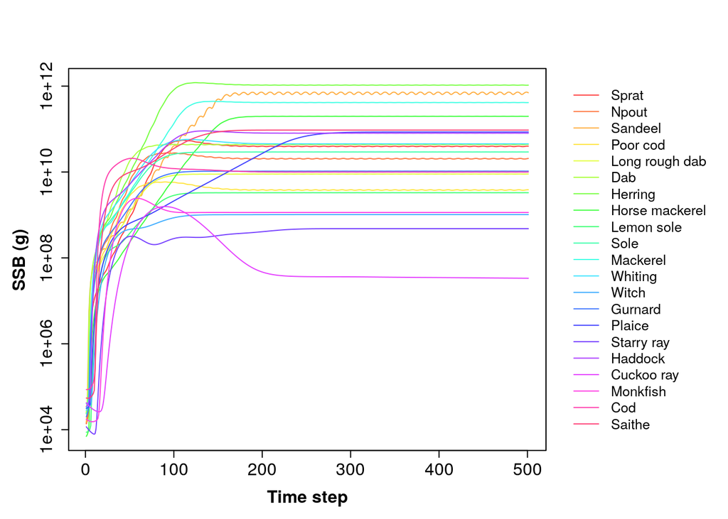

```r
#NS_par: species growth and co
#tau: interaction matrix (row prey columns predator if 1 ij means j eat i)
#eta: steepness of the catchability curve
#L50: length @50% of the max catchability of the catchability curve
#other: amount of other food available for prey not in the model (in g)
#mortality: background mortality M1, pred mortality M2, fishing mort F
#see help for the description for the other parameters
#effort
effort <- matrix(0.25, 50, dim(NS_params @Qs)[3])
#4 gears
model_run <- run_LeMans(NS_params, years=50, effort=effort)
plot_SSB(NS_params,model_run)
```

## Simulation : biology and fishery

The biological model follows the example given by the library. The fishery models follows the package’s vignette example : 4 gears with different species preference and catchability curves are used at a very low effort (0.25 at the model scale). This low level of exploitation let the biological model fluctuates only based on the population processes.

```r
## mixed fishery
## setup the model
NS_params <- LeMansParam(df=NS_par, gdf = NS_mixed_fish, tau=NS_tau, eta=NS_eta, L50=NS_L50, other=NS_other)
```

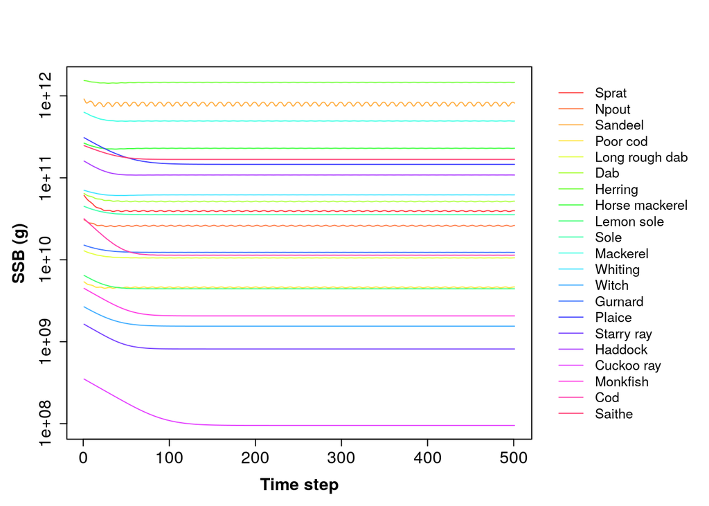

```r
#gear and effort definition (0 -> no fishery)
effort <- matrix(0, 50, dim(NS_params@Qs)[3])
colnames(effort) <- c("Industrial", "Otter", "Beam", "Pelagic")
### run the initial 50 years with no fishery
model_run <- run_LeMans(NS_params, years=50, effort=effort)
#define a very low fishing effort
ef<-as.numeric(rep(0.25,4))
effort_mat <- matrix(ef, 50, dim(NS_params@Qs)[3], byrow=T)
colnames(effort_mat) <- c("Industrial", "Otter", "Beam", "Pelagic")
### run the model
model_run <- run_LeMans(params=NS_params, N0=model_run@N[,,501], years=50, effort=effort_mat)
#plot SSB and biomass
plot_SSB(inputs=NS_params,outputs=model_run,full_plot_only=T)
```

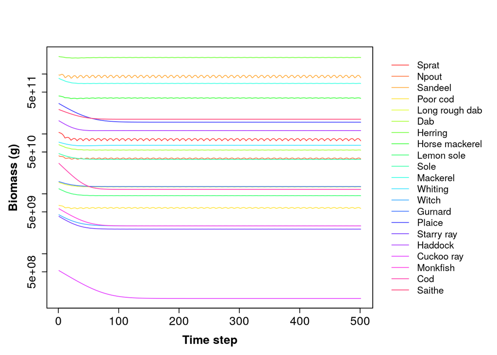

```r
#png("rezbiomass.png")
plot_biomass(inputs=NS_params,outputs=model_run,full_plot_only=T)
```

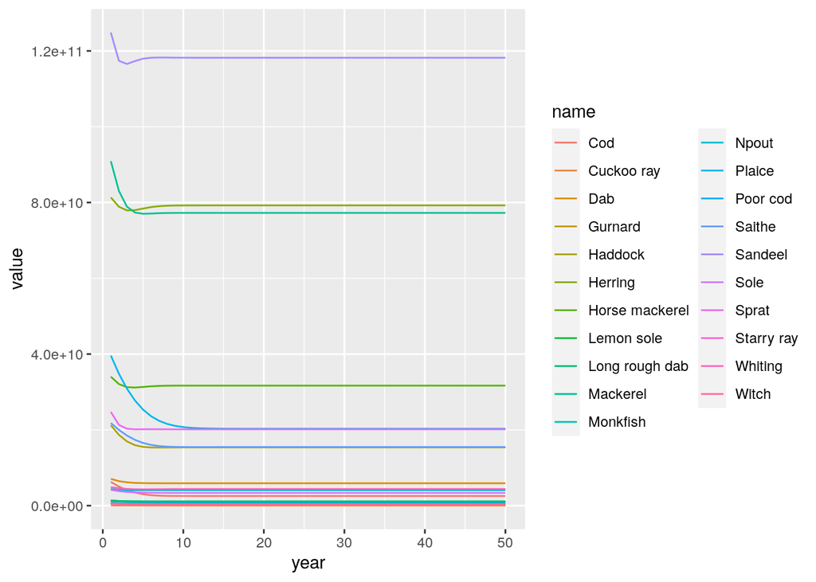

```r
#dev.off()

#get annual catch per gear dim i species j gear k timestep
ycatch<-data.frame((get_annual_catch(NS_params,outputs=model_run)))
colnames(ycatch)<-NS_params@species_names
ycatch$year<-1:50
pipo<-tidyr::pivot_longer(ycatch,cols=1:length(NS_params@species_names))
ggplot(pipo,aes(x=year,y=value,color=name))+geom_line()
```

```r
#get catch per gear
cpg0<-get_CPG(inputs=NS_params,outputs=model_run,effort=effort_mat,years=50)
#add names to pivot_longer the array
attr(cpg0,"dimnames")[[1]]<-NS_params@species_names
attr(cpg0,"dimnames")[[2]]<-names(data.frame(effort_mat))
phi_min<-0.1
nbstep<-dim(cpg0)[3]
nbyear<-(nbstep)*phi_min
idyear<-ceiling(((1:(nbyear/phi_min))*phi_min))
attr(cpg0,"dimnames")[[3]]<-paste0("Y",idyear)
cpg0long<-data.frame(ftable(cpg0))%>%
    transmute(spp=as.character(Var1),
          year=as.numeric(sub("Y","",as.character(Var3))),
          gear=as.character(Var2),
          value=Freq)%>%
    group_by(spp,year,gear)%>%summarise(value=sum(value,na.rm=T))%>%
    ungroup()
```

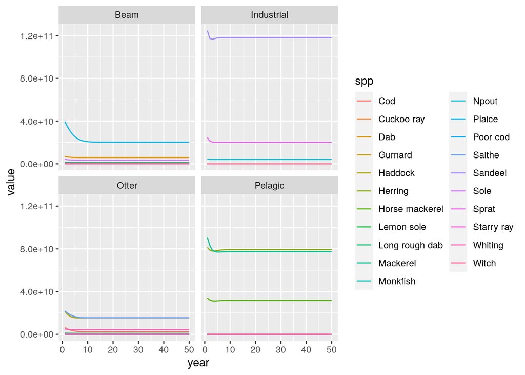

```r
#png("rezcatch.png")
ggplot(cpg0long,aes(x=year,y=value,color=spp))+geom_line()+facet_wrap(~gear)
```

```r
#dev.off()

#build a function to get number at len by gear {{{
#parameters
get_NPG<-function(Catch,Qs,effort,years=nrow(effort),phi_min=0.1){
#if(F){
#Catch<-model_run@N
#Qs<-NS_params@Qs
#effort<-effort_mat
#years<-nrow(effort)
#ph_min<-0.1
#}
    Catch<-Catch[,,-1]
        tot_time <- dim(Catch)[3]
        Fs <- array(0, dim=c(dim(Catch)[1], dim(Catch)[2], tot_time,dim(Qs)[3]))
        year <- ceiling(1:tot_time*phi_min)
    dimnames(Fs)[[4]] <- colnames(effort)
    for (j in colnames(effort)) {
      for (ts in 1:tot_time) {
        Fs[,,ts,j] <- effort[year[ts], j]*Qs[,,j]
      }
    }
    #norm of fishing mort
    tele0<-Fs
            for (ts in 1:tot_time) {
              tmp <- apply(Fs[,,ts,], c(1,2), sum)
              for(j in 1:dim(tele0)[4]) {
                tele <- Fs[,,ts,j]/tmp
                if (any(is.na(tele))) {
                  tele[is.na(tele)] <- 0
                }
        tele0[,,ts,j]<-tele
              }
        }
    #get N fish by gear
    NPG<-tele0
        for(j in 1:dim(tele0)[4]) {
        NPG[,,,j]<-tele0[,,,j]*Catch
    }
    attr(NPG,"dimnames")[[1]]<-paste0("L",NS_params@u_bound)
    attr(NPG,"dimnames")[[2]]<-NS_params@species_names
    nbstep<-dim(NPG)[3]
    nbyear<-(nbstep)*phi_min
    idyear<-ceiling(((1:(nbyear/phi_min))*phi_min))
    attr(NPG,"dimnames")[[3]]<-paste0("Y",idyear)
    return(NPG)
}#}}}
npg0<-get_NPG(Catch=model_run@N,Qs=NS_params@Qs,effort=effort_mat,years=nrow(effort),phi_min=0.1)

npg0long<-data.frame(ftable(npg0))%>%
    transmute(len=as.numeric(sub("L","",as.character(Var1))),
          spp=as.character(Var2),
          year=as.numeric(sub("Y","",as.character(Var3))),
          gear=as.character(Var4),
          value=Freq)%>%
    group_by(len,spp,year,gear)%>%summarise(value=sum(value,na.rm=T))%>%
    ungroup()
```

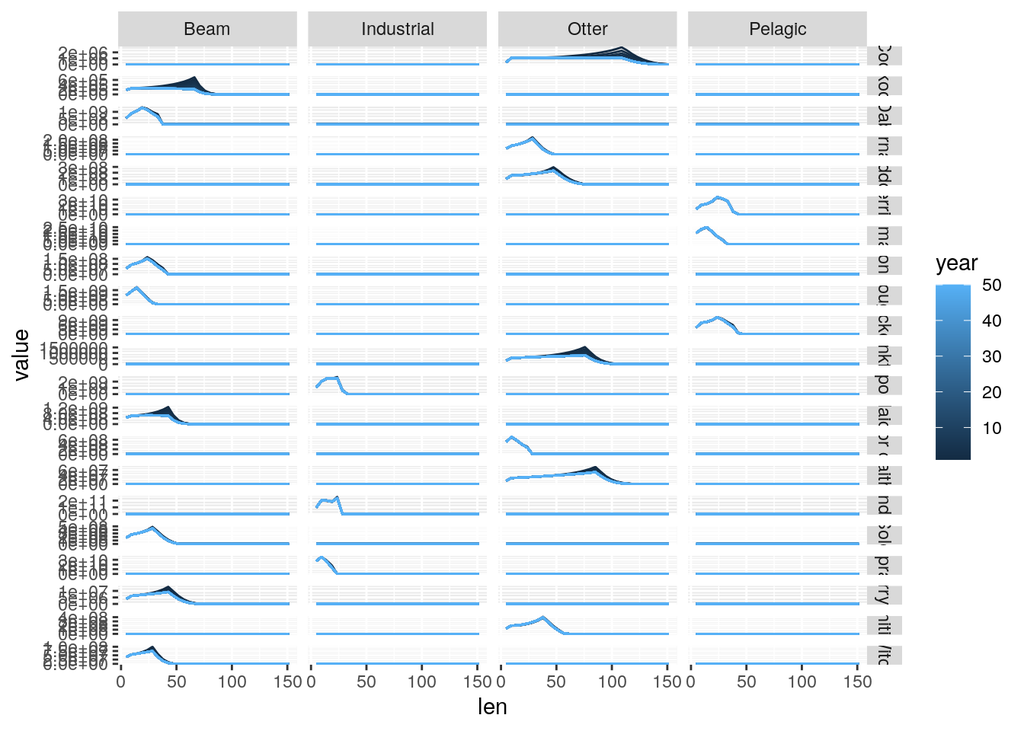

```r
#plot the len distrib by year/gear/years
ggplot(npg0long,aes(x=len,y=value,color=year,group=year))+geom_line()+facet_grid(spp~gear,scales="free")
```

```r
#ggsave("reznlenpop.png")
```

## Simulation : detailed fishery activities

As it is, LeMaRns models produces bulk catches by gear. The following code details the fishery catches by vessels, trips and fishing operation. These units are generated randomly following some inputs parameters. In this report there are 4 Beam, 2 Industrial, 4 Otter and 3 Pelagic vessels. Each of them do randomly 1 to 20 trips a year, in which 1 to 20 fishing operations occurs. The number of active vessels by year vary from 1 to the maximum of number of the considered gear. Biological parameters are added to the simulation (fish weights, ages…). The catch for each fishing operation is a fraction of the total catch of the gear, taken randomly and normalized to keep the total catch of the gear equal to the LeMaRns total catches.

```r
#improvment: generating trrrrip for the whole pop and sampling theeeeeeem
#npg0long,NS_params,n1=20,nbvess=data.frame(gear=c("Beam","Industrial","Otter","Pelagic"),nvess=c(4,2,4,3))
#ntrip is 1:n1
    #add vessel vessel trip proportionnal
    tr0<-npg0long%>%select(year,gear)%>%distinct()
    #generate a vessel population and related trip
    nbvess<-data.frame(gear=c("Beam","Industrial","Otter","Pelagic"),nvess=c(4,2,4,3))
    #generate up to 20 FO by gear and gear and up to max fo trip
    nfo<- tr0%>%rowwise()%>%mutate(nfo=sample(1:20,1))%>%
        mutate(ntrip=sample(1:nfo,1,replace=T))%>%
        ungroup()%>%
        left_join(nbvess)
    #trip id + FO id
    nfo<-nfo[rep(1:nrow(nfo),times=nfo$nfo),]%>%
        group_by(year,gear,nfo)%>%
        mutate(FOid=row_number())%>%ungroup()%>%
        rowwise()%>%
        mutate(TRid=sample(1:ntrip,1,replace=TRUE))%>%
        group_by(year,gear,TRid)%>%
        mutate(FOid=row_number())%>%ungroup()%>%
        arrange(year,gear,TRid,FOid)%>%
        ungroup()
    #separate elaboration of vess id (unique by trip: trick for that)
    nvesstmp<-nfo%>%select(year,gear,TRid,nvess)%>%distinct()%>%
        rowwise()%>%mutate(VDid=sample(1:nvess,1,replace=T))%>%
        ungroup()
    nall<-nfo%>%left_join(nvesstmp)
    #generate the prop of the catch taken by each FO
    nall<-nall%>%group_by(year,gear)%>%mutate(prop=runif(nfo))%>%
        mutate(prop=prop/sum(prop))%>%ungroup()
    #pipo%>%group_by(year,gear)%>%summarise(tot=sum(prop))%>%filter(tot!=1)
    npg0longsim<-left_join(nall,npg0long)%>%mutate(value=value*prop)%>%
        filter(value>0)%>%select(-prop)
    #add nspp tot
    npg0longsim<-npg0longsim%>%
        group_by(year,gear,FOid,TRid,VDid)%>%
        mutate(nspp=n_distinct(spp))%>%
        group_by(year,gear,TRid,VDid)%>%
        mutate(nfo=n_distinct(FOid))%>%
        group_by(year,gear,VDid)%>%
        mutate(ntrip=n_distinct(TRid))%>%
        group_by(year,gear)%>%
        mutate(nvess=n_distinct(VDid))%>%
        ungroup()


    #check
    pipo1<-npg0longsim%>%group_by(year,gear,len,spp)%>%summarise(value0=sum(value))%>%ungroup()
    uu<-full_join(pipo1,npg0long)%>%filter(abs(value0-value)>1)
    if(nrow(uu)>0){strop("pb trip prop")}
    #npg0longsim%>%filter(year==1,gear=="Beam",FOid==1,TRid==1,VDid==1)
    #add biological information
    lwa<-data.frame(spp=NS_params@species_names,a=NS_params@W_a,b=NS_params@W_b,
            Linf=NS_params@Linf,k=NS_params@k)
    npg0longsim<-npg0longsim%>%left_join(lwa)
```

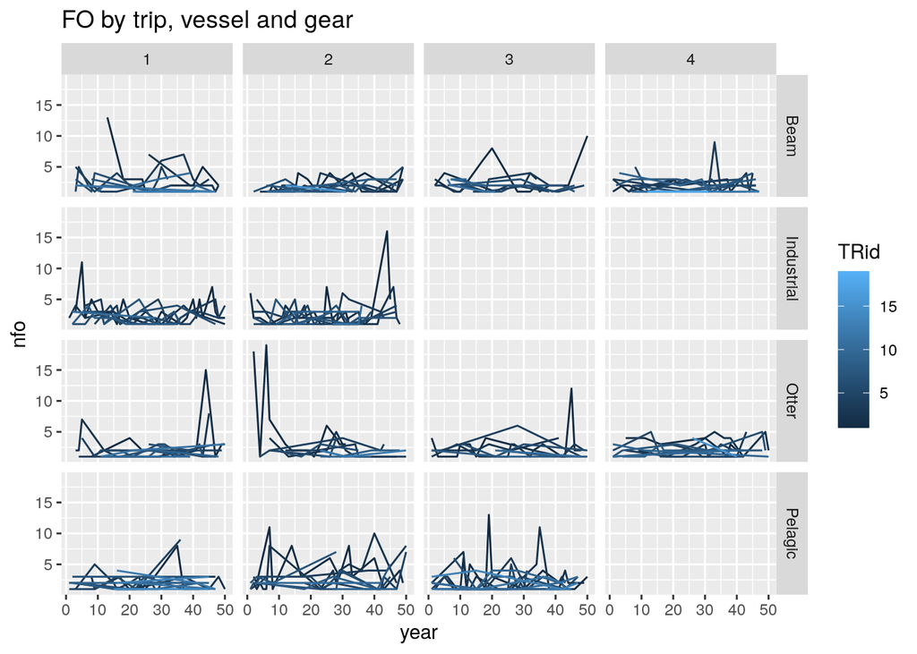

```r
    npg0longsim$wind<-npg0longsim$a*npg0longsim$len^npg0longsim$b
    #add age
    fct1<-function(t0=0,K,Linf,L){ max(1, ((-log(1 - L/Linf))/K + t0))}
    npg0longsim<-npg0longsim%>%mutate(lentmp=ifelse(len>Linf,Linf-1e-1,len))%>%
        rowwise()%>%
        mutate(age=fct1(0,k,Linf,lentmp))%>%
        ungroup()
    #ggplot(npg0longsim,aes(x=len,y=age,group=spp,color=spp))+geom_point()
    #add to w by spp
    npg0longsim<-npg0longsim%>%mutate(wspp=value*wind)
    #clean the data
    npg0longsim<-npg0longsim%>%transmute(year,gear,nspp,nfo,ntrip,nvess,FOid,TRid,VDid,spp,len,age,
                      n=value,wind,wspp)
    reztmp<-npg0longsim%>%select(year,gear,VDid,TRid,FOid)%>%distinct()%>%
        group_by(year,gear,VDid,TRid)%>%summarise(nfo=n_distinct(FOid))%>%
        ungroup()
    ggplot(reztmp,aes(x=year,y=nfo,group=TRid,color=TRid))+
        geom_path()+facet_grid(gear~VDid)+
        ggtitle("FO by trip, vessel and gear")
```

## Simulation : sampling the simulated fishery activities

```r
    #sampling scheme
    #nb vessel, nbtrip ,n FO and prop sampled
    nplanVD<-2;nplanTR<-1;nplanFO<-seq(1,max(npg0longsim$nfo),2);
    nplanSPP<-15;planprop<-0.1
    #sample space
    sampspace<-npg0longsim%>%select(year,gear,spp,FOid,TRid,VDid)%>%
        distinct()
    #random sampling of 2 vessels by strata
    sampVD<-sampspace%>%select(year,gear,VDid)%>%
        distinct()%>%
        group_by(year,gear)%>%
        slice_sample(n=nplanVD,replace=F)%>%
        ungroup()%>%
        mutate(VDsamp=TRUE)
    sampspace<-left_join(sampspace,sampVD)%>%mutate(VDsamp=ifelse(is.na(VDsamp),F,VDsamp))
    #weighted random sampling of 1 trip by vessels by strata (aka the vessel
    #with the more trip are highest proba of selection)
    sampTR<-sampspace%>%filter(VDsamp==T)%>%select(year,gear,VDid,TRid)%>%
        distinct()%>%
        group_by(year,gear,VDid)%>%mutate(nbtrip=n_distinct(TRid))%>%
        group_by(year,gear,VDid)%>%
        slice_sample(n=nplanTR,weight_by=nbtrip,replace=F)%>%
        ungroup()%>%
        mutate(TRsamp=TRUE)%>%
        select(-nbtrip)
    sampspace<-left_join(sampspace,sampTR)%>%mutate(TRsamp=ifelse(is.na(TRsamp),F,TRsamp))
    #take one FO on 3
    sampspace<-sampspace%>%
        mutate(FOsamp=VDsamp&TRsamp&FOid%in%nplanFO)
    #plan to sample 10% of the catch
    sampspace<-sampspace%>%
        mutate(propsamp=ifelse(FOsamp,planprop,0))
    #take n species over the whole species there
    sampSPP<-sampspace%>%filter(VDsamp==T&TRsamp&FOsamp==T)%>%select(year,gear,VDid,TRid,FOid,spp)%>%
        distinct()%>%
        group_by(year,gear,VDid,TRid,FOid)%>%mutate(nbspp=n_distinct(spp))%>%
        group_by(year,gear,VDid,TRid,FOid)%>%
        slice_sample(n=nplanSPP,replace=F)%>%
        ungroup()%>%
        mutate(SPPsamp=TRUE)%>%
        select(-nbspp)
    #sampSPP%>%filter(year==1,gear=="Beam")
    #merge
    sampspace<-left_join(sampspace,sampSPP)%>%mutate(SPPsamp=ifelse(is.na(SPPsamp),F,SPPsamp))
    #add the sampling plan to npglon
    npg0longsim<-left_join(npg0longsim,sampspace)
    #compute subtotal for some parameters
    npg0longsim<-npg0longsim%>%
        group_by(year,gear,FOid,TRid,VDid)%>%
        mutate(wFO=sum(wspp))%>%
        group_by(year,gear,TRid,VDid)%>%
        mutate(wTR=sum(wspp))%>%
        group_by(year,gear,VDid)%>%
        mutate(wVD=sum(wspp))%>%
        ungroup()
    #check
    #npg0longsim%>%filter(year==1,gear=="Beam",VDid==2)%>%select(wVD)%>%unique()%>%pull
    #npg0longsim%>%filter(year==1,gear=="Beam",VDid==2)%>%select(TRid,wTR)%>%distinct()%>%pull(wTR)%>%sum()
    #npg0longsim%>%filter(year==1,gear=="Beam",VDid==2)%>%select(FOid,wFO)%>%distinct()%>%pull(wFO)%>%sum()
    #sum(npg0longsim$wspp)
    #npg0longsim%>%select(gear,year,VDid,wVD)%>%distinct()%>%pull(wVD)%>%sum()
    #npg0longsim%>%select(gear,year,VDid,TRid,wTR)%>%distinct()%>%pull(wTR)%>%sum()
    #npg0longsim%>%group_by(year,gear,nfo,ntrip,nvess,FOid,TRid,VDid)%>%summarise(nbfo=n_distinct(FOid))

    #npg0longsim%>%select(year,gear,VDid,TRid,FOid,nspp,nfo,ntrip,nvess)%>%arrange(year,gear,VDid,TRid,FOid)%>%distinct()
    tmp<-npg0longsim%>%filter(FOsamp==T)%>%
        group_by(year,gear,len,spp)%>%
        summarise(n=sum(n*propsamp))%>%
        ungroup()
```

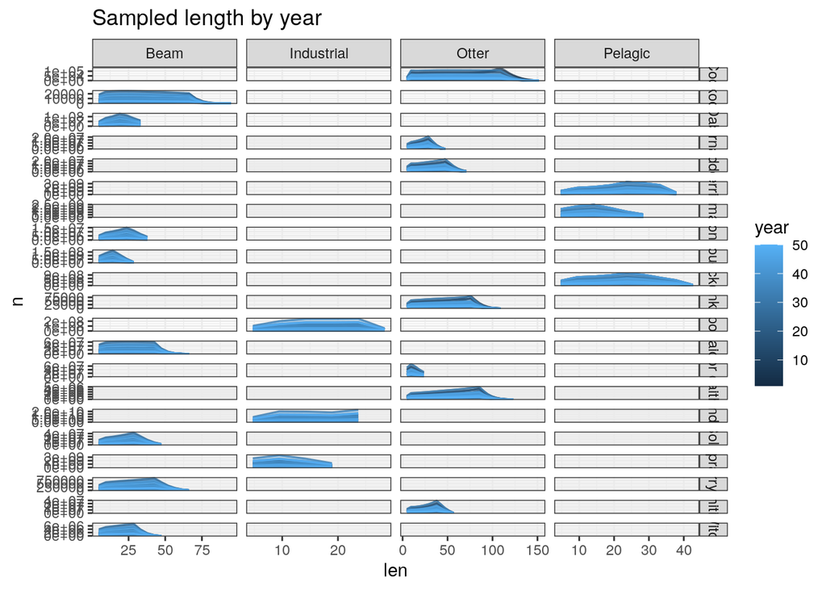

```r
    #plot the len distrib by year/gear/years
    ggplot(tmp,aes(x=len,y=n,color=year,group=year))+
        geom_line(alpha=0.7)+
        facet_grid(spp~gear,scales="free")+
        ggtitle("Sampled length by year")+
        theme_bw()
```

# Outputs

Simulated population data and sampling are saved.

```r
saveRDS(npg0longsim,file="./outputs/datasimu.rds")
#truc for CL
saveRDS(cpg0long,file="./outputs/datapop.rds")
saveRDS(npg0long,file="./outputs/datapopn.rds")
```

# References

Hall, Stephen J., Jeremy S. Collie, Daniel E. Duplisea, Simon Jennings, Mark Bravington, and Jason Link. 2006. “A Length-Based Multispecies Model for Evaluating Community Responses to Fishing.” *Canadian Journal of Fisheries and Aquatic Sciences*, June. https://doi.org/10.1139/f06-039.

Spence, Michael A., Hayley J. Bannister, Johnathan E. Ball, Paul J. Dolder, Christopher A. Griffiths, and Robert B. Thorpe. 2020. “LeMaRns: A Length-Based Multi-Species Analysis by Numerical Simulation in R.” *PLOS ONE* 15 (2): e0227767. https://doi.org/10.1371/journal.pone.0227767.

Thorpe, Robert B., Will J. F. Le Quesne, Fay Luxford, Jeremy S. Collie, and Simon Jennings. 2015. “Evaluation and Management Implications of Uncertainty in a Multispecies Size-Structured Model of Population and Community Responses to Fishing.” *Methods in Ecology and Evolution* 6 (1): 49–58. https://doi.org/10.1111/2041-210X.12292.

Thorpe, Robert Brian, Paul James Dolder, Stuart Reeves, Peter Robinson, and Simon Jennings. 2016. “Assessing Fishery and Ecological Consequences of Alternate Management Options for Multispecies Fisheries.” *ICES Journal of Marine Science* 73 (6): 1503–12. https://doi.org/10.1093/icesjms/fsw028.